icfes: competencia: - formulacion_ejecucion nivel_dificultad: 3 contenido: categoria: geometria tipo: no_generico contexto: matematico eje_axial: eje2 componente: geometrico_metrico

```r
options(OutDec = ".")  # Asegurar punto decimal en este chunk

# Establecer semilla aleatoria
set.seed(sample(1:10000, 1))

# Aleatorizamos los nombres para contextualizar el problema
nombres <- c("Camilo", "Andrés", "Sofía", "Manuel", "Laura", "Carlos",
             "Daniela", "Miguel", "Valentina", "Eduardo", "Natalia",
             "José", "Isabella", "Gabriel", "Mariana", "Santiago", "Lucía",
             "Alejandro", "Catalina", "Mateo", "Valeria", "Sebastián", "Juliana")
nombre <- sample(nombres, 1)

# Aleatorizamos los tipos de recipientes
recipientes <- c("cilindro", "tubo", "conducto", "tanque cilíndrico",
                 "recipiente cilíndrico", "contenedor cilíndrico",
                 "ducto cilíndrico", "depósito cilíndrico", "cañería cilíndrica")
recipiente <- sample(recipientes, 1)

# Aleatorizar adjetivos para el cilindro interno
adjetivos_interno <- c("interno", "hueco", "vacío", "interior", "central", "medio")
adjetivo_interno <- sample(adjetivos_interno, 1)

# Aleatorizar líquidos
liquidos <- c("aceite", "combustible", "líquido", "fluido", "agua", "refrigerante",
              "solución", "mezcla", "sustancia")
liquido <- sample(liquidos, 1)

# Aleatorizar lo que se desea calcular
calculos <- c("la cantidad de", "el volumen de", "cuánto", "qué cantidad de",
              "cuántos litros de", "qué volumen de", "la capacidad de")
calculo <- sample(calculos, 1)

# Aleatorizar verbos para la acción
verbos <- c("llenar", "contener", "almacenar", "ocupar", "requerir")
verbo <- sample(verbos, 1)

# Aleatorizar medidas del cilindro (manteniendo consistencia matemática)
# Primero generamos el radio interno (entre 0.1 y 0.4 metros)
r_int <- round(runif(1, 0.1, 0.4), 2)

# Luego generamos el radio externo, asegurando que sea mayor que el interno
# Radio externo entre 1.5 y 2.5 veces el radio interno
factor_radio <- runif(1, 1.5, 2.5)
r_ext <- round(r_int * factor_radio, 2)

# Calculamos el diámetro externo (exactamente 2 veces el radio externo)
d_ext <- 2 * r_ext

# Altura del cilindro (entre 0.5 y 4 metros)
altura <- round(runif(1, 0.5, 4), 2)

# Calcular el grosor de la pared del cilindro
grosor <- r_ext - r_int

# Verificar coherencia física
if (grosor < 0.05) {
  # Asegurar un grosor mínimo de 0.05 unidades
  grosor <- round(runif(1, 0.05, 0.2), 2)
  r_ext <- r_int + grosor
  # Asegurar que el diámetro externo sea exactamente 2 veces el radio externo
  d_ext <- 2 * r_ext
}

# Calcular el volumen necesario (es el volumen del cilindro interior)
volumen <- round(pi * (r_int^2) * altura, 2)

# Aleatorizar unidades de medida
unidades_longitud <- c("m", "cm", "dm")
unidad <- sample(unidades_longitud, 1)

# Ajustar valores según la unidad
factor_conversion <- 1
if (unidad == "cm") {
  factor_conversion <- 100
  d_ext <- d_ext * factor_conversion
  r_int <- r_int * factor_conversion
  altura <- altura * factor_conversion
  volumen <- volumen * (factor_conversion^3)
  r_ext <- r_ext * factor_conversion
} else if (unidad == "dm") {
  factor_conversion <- 10
  d_ext <- d_ext * factor_conversion
  r_int <- r_int * factor_conversion
  altura <- altura * factor_conversion
  volumen <- volumen * (factor_conversion^3)
  r_ext <- r_ext * factor_conversion
}

# Redondear todos los valores para mayor claridad
d_ext <- round(d_ext, 1)
r_int <- round(r_int, 1)
altura <- round(altura, 1)
r_ext <- round(r_ext, 1)
volumen <- round(volumen, 1)

# La respuesta correcta es "C) Altura del cilindro"
# Ya que para calcular el volumen necesitaríamos conocer la altura
opcion_correcta <- 3 # Índice de "Altura del cilindro" en el vector de opciones

# Vector de solución para r-exams (1 para la correcta, 0 para las incorrectas)
solucion <- c(0, 0, 1, 0)
```

```r
options(OutDec = ".")  # Asegurar punto decimal en este chunk

# Código Python para generar el cilindro hueco adaptado del archivo Cilindro-Hueco.py
codigo_python <- paste0("
import matplotlib.pyplot as plt
import numpy as np
from matplotlib.patches import Ellipse, FancyArrowPatch, ConnectionPatch
import matplotlib.patheffects as path_effects
from matplotlib.patches import Rectangle

# Parámetros del cilindro
radio_interno = ", r_int, "  # ", unidad, "
grosor = ", r_ext - r_int, "  # ", unidad, "
radio_externo = radio_interno + grosor  # ", r_ext, " ", unidad, "
altura = ", altura, "  # ", unidad, "
diametro_externo = 2 * radio_externo  # ", d_ext, " ", unidad, "
unidad = '", unidad, "'

# Calcular la relación altura/radio para ajustar dinámicamente la visualización
relacion_altura_radio = altura / radio_externo

# Ajustar el tamaño de la figura según la relación altura/radio
if relacion_altura_radio > 5:
    fig_width = 7
    fig_height = 8
elif relacion_altura_radio > 3:
    fig_width = 7
    fig_height = 7
else:
    fig_width = 6
    fig_height = 6

# Crear figura con las proporciones adecuadas
fig, ax = plt.subplots(figsize=(fig_width, fig_height))

# Vertical radii for perspective (ellipses) - ajustados dinámicamente
factor_perspectiva = min(0.4, max(0.2, 1.0/relacion_altura_radio))
vradioexternobot = radio_externo * factor_perspectiva  # Radio vertical de la elipse externa inferior
vradiointernobot = radio_interno * factor_perspectiva  # Radio vertical de la elipse interna inferior
vradioexternotop = radio_externo * factor_perspectiva * 1.2  # Radio vertical de la elipse externa superior
vradiointernotop = radio_interno * factor_perspectiva * 1.2  # Radio vertical de la elipse interna superior

# Definir colores personalizados
cilindroColor = '#3C78B4'  # Azul para el cilindro (RGB 60, 120, 180)
lineaOculta = '#969696'    # Gris para líneas ocultas (RGB 150, 150, 150)
etiquetaColor = '#323232'  # Gris oscuro para etiquetas (RGB 50, 50, 50)

# Coordenadas de los centros de las bases
centroinferior = (0, 0)
centrosuperior = (0, altura)

# Puntos clave en las bases
# Base inferior
R0b = (radio_externo, 0)  # Punto externo derecho inferior
neg_R0b = (-radio_externo, 0)  # Punto externo izquierdo inferior
r0b = (radio_interno, 0)  # Punto interno derecho inferior
neg_r0b = (-radio_interno, 0)  # Punto interno izquierdo inferior

# Base superior
R0t = (radio_externo, altura)  # Punto externo derecho superior
neg_R0t = (-radio_externo, altura)  # Punto externo izquierdo superior
r0t = (radio_interno, altura)  # Punto interno derecho superior
neg_r0t = (-radio_interno, altura)  # Punto interno izquierdo superior

# --- Dibujar partes ocultas (punteadas) ---
# Arco posterior externo inferior
theta = np.linspace(0, np.pi, 100)
x_ext_back = radio_externo * np.cos(theta)
y_ext_back = vradioexternobot * np.sin(theta)
ax.plot(x_ext_back, y_ext_back, linestyle='--', color=lineaOculta, linewidth=0.8)

# Arco posterior interno inferior
x_int_back = radio_interno * np.cos(theta)
y_int_back = vradiointernobot * np.sin(theta)
ax.plot(x_int_back, y_int_back, linestyle='--', color=lineaOculta, linewidth=0.8)

# Líneas verticales internas (ocultas)
ax.plot([neg_r0b[0], neg_r0t[0]], [neg_r0b[1], neg_r0t[1]],
        linestyle='--', color=lineaOculta, linewidth=0.8)
ax.plot([r0b[0], r0t[0]], [r0b[1], r0t[1]],
        linestyle='--', color=lineaOculta, linewidth=0.8)

# --- Dibujar partes visibles ---
# Líneas verticales externas (visibles)
ax.plot([neg_R0b[0], neg_R0t[0]], [neg_R0b[1], neg_R0t[1]],
        color=cilindroColor, linewidth=1.2)
ax.plot([R0b[0], R0t[0]], [R0b[1], R0t[1]],
        color=cilindroColor, linewidth=1.2)

# Arco frontal externo inferior
theta = np.linspace(0, -np.pi, 100)
x_ext_front = radio_externo * np.cos(theta)
y_ext_front = vradioexternobot * np.sin(theta)
ax.plot(x_ext_front, y_ext_front, color=cilindroColor, linewidth=1.2)

# Arco frontal interno inferior
x_int_front = radio_interno * np.cos(theta)
y_int_front = vradiointernobot * np.sin(theta)
ax.plot(x_int_front, y_int_front, color=cilindroColor, linewidth=1.2)

# Elipse externa superior (visible)
top_ext_ellipse = Ellipse(centrosuperior, 2*radio_externo, 2*vradioexternotop,
                         fill=False, edgecolor=cilindroColor, linewidth=1.2)
ax.add_patch(top_ext_ellipse)

# Elipse interna superior (visible)
top_int_ellipse = Ellipse(centrosuperior, 2*radio_interno, 2*vradiointernotop,
                         fill=False, edgecolor=cilindroColor, linewidth=1.2)
ax.add_patch(top_int_ellipse)

# Sombreado sutil para profundidad
# Crear un polígono para el lado visible del cilindro
theta_side = np.linspace(0, -np.pi, 50)
x_side_bottom = radio_externo * np.cos(theta_side)
y_side_bottom = vradioexternobot * np.sin(theta_side)

theta_side_top = np.linspace(np.pi, 0, 50)
x_side_top = radio_externo * np.cos(theta_side_top)
y_side_top = altura + vradioexternotop * np.sin(theta_side_top)

x_side = np.concatenate([x_side_bottom, x_side_top[::-1]])
y_side = np.concatenate([y_side_bottom, y_side_top[::-1]])

ax.fill(x_side, y_side, color=cilindroColor, alpha=0.1)

# --- Dimensiones y etiquetas ---
# Calcular espaciado adaptativo para etiquetas
espacio_etiqueta = min(0.15 * altura, max(0.05 * altura, radio_externo * 0.3))

# Altura
# Calcular posiciones adaptativas para la flecha de altura
altura_inicio = (R0b[0] + espacio_etiqueta, R0b[1])
altura_fin = (R0t[0] + espacio_etiqueta, R0t[1])

# Dibujar línea de medición de altura con flechas
height_line = FancyArrowPatch(altura_inicio, altura_fin,
                             arrowstyle='<->', linewidth=0.9,
                             color=etiquetaColor, mutation_scale=10)
ax.add_patch(height_line)

# Etiqueta de altura
altura_label_pos = ((altura_inicio[0] + altura_fin[0])/2 + espacio_etiqueta*0.5,
                    (altura_inicio[1] + altura_fin[1])/2)
ax.text(altura_label_pos[0], altura_label_pos[1], 'Altura',
        color=etiquetaColor, fontweight='bold', ha='left', va='center',
        bbox=dict(facecolor='white', edgecolor='none', boxstyle='round,pad=0.3'))

# Radio interno
# Dibujar línea de radio interno
internal_radius_line = FancyArrowPatch(centrosuperior, r0t,
                                      arrowstyle='->', linewidth=0.9,
                                      color=cilindroColor, alpha=0.8, mutation_scale=10)
ax.add_patch(internal_radius_line)

# Calcular posición adaptativa para etiqueta de radio interno
pos_y_radio_interno = altura + espacio_etiqueta * 2
if relacion_altura_radio > 4:
    pos_y_radio_interno = altura - espacio_etiqueta * 0.5

# Etiqueta de radio interno con fondo blanco
ax.text(radio_interno/2, pos_y_radio_interno,
        f'Radio interno = {radio_interno} {unidad}', color=etiquetaColor,
        fontweight='bold', ha='center', va='center',
        bbox=dict(facecolor='white', edgecolor='none', boxstyle='round,pad=0.3'))

# Grosor
# Calcular posición adaptativa para la etiqueta de grosor
pos_grosor_y = altura * 0.5  # Siempre en la mitad de la altura

# Dibujar línea de medición de grosor
thickness_line = FancyArrowPatch(neg_r0t, neg_R0t,
                                arrowstyle='<->', linewidth=0.9,
                                color=etiquetaColor, mutation_scale=10)
ax.add_patch(thickness_line)

# Etiqueta de grosor con fondo blanco
etiqueta_grosor_pos = (-radio_externo - espacio_etiqueta, pos_grosor_y)
ax.text(etiqueta_grosor_pos[0], etiqueta_grosor_pos[1],
        f'Grosor = {grosor} {unidad}', color=etiquetaColor,
        fontweight='bold', ha='right', va='center',
        bbox=dict(facecolor='white', edgecolor='none', boxstyle='round,pad=0.3'))

# Diámetro externo
# Calcular posiciones adaptativas para la flecha de diámetro
diam_ext_izq = (neg_R0t[0], neg_R0t[1] + espacio_etiqueta)
diam_ext_der = (R0t[0], R0t[1] + espacio_etiqueta)

# Dibujar línea de medición de diámetro
diameter_line = FancyArrowPatch(diam_ext_izq, diam_ext_der,
                               arrowstyle='<->', linewidth=0.9,
                               color=etiquetaColor, mutation_scale=10)
ax.add_patch(diameter_line)

# Etiqueta de diámetro con fondo blanco
etiqueta_diametro_pos = (0, altura + espacio_etiqueta * 2)
ax.text(etiqueta_diametro_pos[0], etiqueta_diametro_pos[1],
        f'Diámetro externo = {diametro_externo} {unidad}', color=etiquetaColor,
        fontweight='bold', ha='center', va='center',
        bbox=dict(facecolor='white', edgecolor='none', boxstyle='round,pad=0.3'))

# Radio externo
# Dibujar línea de radio externo
external_radius_line = FancyArrowPatch(centroinferior, R0b,
                                      arrowstyle='->', linewidth=0.9,
                                      color=cilindroColor, alpha=0.8, mutation_scale=10)
ax.add_patch(external_radius_line)

# Etiqueta de radio externo con fondo blanco
etiqueta_radio_externo_pos = (radio_externo/2, -espacio_etiqueta)
ax.text(etiqueta_radio_externo_pos[0], etiqueta_radio_externo_pos[1],
        f'Radio externo = {radio_externo} {unidad}', color=etiquetaColor,
        fontweight='bold', ha='center', va='center',
        bbox=dict(facecolor='white', edgecolor='none', boxstyle='round,pad=0.3'))

# Ajustar límites dinámicamente basados en las proporciones del cilindro
margen_x = max(radio_externo * 0.5, espacio_etiqueta * 2)
margen_y = max(altura * 0.2, espacio_etiqueta * 3)

ax.set_xlim(-radio_externo - margen_x, radio_externo + margen_x * 1.5)
ax.set_ylim(-margen_y, altura + margen_y)

# Desactivar la relación de aspecto igual para cilindros muy altos
if relacion_altura_radio > 4:
    # No usar axis('equal') para cilindros muy altos
    pass
else:
    ax.set_aspect('equal')  # Mantener para cilindros con proporciones normales

# Eliminar ejes
ax.axis('off')

# Optimizar el layout para eliminar espacios vacíos
plt.tight_layout(pad=0.5)
# Guardar con recorte ajustado y mayor resolución para mantener calidad
plt.savefig('cilindro_hueco.png', dpi=180, bbox_inches='tight', pad_inches=0.1)
plt.close()
")

# Ejecutar código Python para generar la figura
py_run_string(codigo_python)
```

# Question

Camilo desea saber cuánto(a) líquido se necesita para llenar un contenedor cilíndrico interno, pero solamente cuenta con las medidas de las dimensiones que muestra la figura.

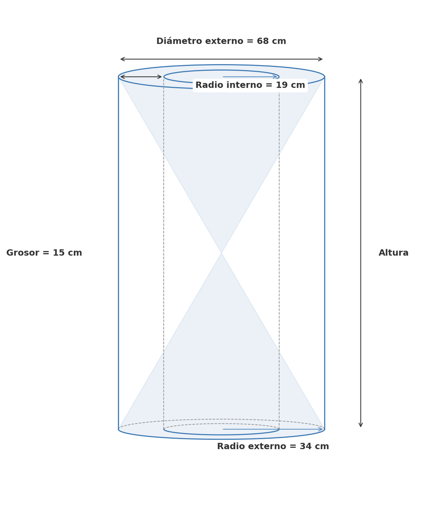

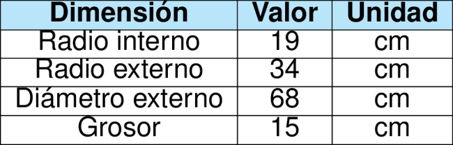

¿Cuál medida le falta a Camilo para hallar la cantidad deseada?

## Answerlist

- Radio externo.
- Diámetro externo.
- Altura del cilindro.
- Perímetro del cilindro.

# Solution

La respuesta correcta es: **Altura del cilindro**.

Para calcular el volumen de líquido necesario para llenar el contenedor cilíndrico vacío, necesitamos calcular el volumen de un cilindro, cuya fórmula es:

$V = \pi \cdot r^2 \cdot h$

Donde: - $r$ es el radio (en este caso, el radio interno = 19 cm) - $h$ es la altura del cilindro

En el problema se nos proporciona: - Diámetro externo = 68 cm - Radio interno = 19 cm

Sin embargo, no se nos proporciona la altura del cilindro, que es esencial para calcular el volumen. Por lo tanto, a Camilo le falta conocer la altura del cilindro para poder calcular la cantidad de líquido necesaria.

Si tuviéramos la altura, el volumen se calcularía así: $V = \pi \cdot (19)^2 \cdot h = 1134,11 \cdot h$ cm³

## Answerlist

- Falso
- Falso
- Verdadero
- Falso

# Meta-information

exname: volumen_cilindro_hueco extype: schoice exsolution: 0010 exshuffle: TRUE exsection: Geometría|Volumen|Cilindro